# Dataset Joyce_2019_Cm

This dataset is from Joyce et al. (2019): https://doi.org/10.1016/j.marenvres.2019.02.010

- Contains n=67 feeding trials.
- Raw data is available.
- Single-prey experiments ran for 8 hours, multi-prey for 2 hours.
- Eaten prey were not replaced during single-prey experiments, but replaced in multi-prey.
- We fitted a mix of ODE-based predictions and direct FR predictions, accordingly.
- Holling-2 was identified as the best fitting model. Holling-3 and the New FR performed equally.
- The model predicts a preference for prey 1, no switching.
- Multi-prey data was systematically under-predicted. This is likely because of strong diffences in experimental duration.

## Setup

```r
rm(list=ls())
library("rstan")
library("loo")
library("coda")
library("deSolve")
library("BayesianTools")
library("readxl")
```

Load MSFR functions that can be used with the `deSolve` package, used for posterior predictions later.

```r
source("desolve_models.R")
```

Compile Stan models. Can be skipped if already executed before, models are saved in `.Rdata` files.

```r
source("compilation_loo_mixed.R")
```

Load compiled Stan models.

```r
load("stan_model_H2_mixed.RData")
load("stan_model_H3_mixed.RData")
load("stan_model_Yo_mixed.RData")
load("stan_model_New_mixed.RData")
```

## Prepare data

`df.all` includes all observations, `df.multi` only multi-species experiments, `df.single.1` and `df.single.2` only single-species experiments, respectively.

```r
df = read_excel("1-s2.0-S0141113619300224-mmc2.xlsx", skip=1) |> as.data.frame()
head(df)
```

```
  predator...1 prey species supplied alive consumed ...6 ...7 predator...8
1    A. rubens       mussel        1     0        1   NA   NA    A. rubens
2    A. rubens       mussel        1     0        1   NA   NA    A. rubens
3    A. rubens       mussel        1     1        0   NA   NA    A. rubens
4    A. rubens       mussel        2     0        2   NA   NA    A. rubens
5    A. rubens       mussel        2     0        2   NA   NA    A. rubens
6    A. rubens       mussel        2     0        2   NA   NA    A. rubens
  mussels supplied oysters supplied mussels consumed oysters consumed
1               20                0                5                0
2               20                0                8                0
3               20                0               11                0
4               15                5               12                2
5               15                5                1                0
6               15                5                5                0
```

```r
df.single = df[, 1:5]
colnames(df.single)[1] = "predator"
df.single = subset(df.single, predator=="C. maenas")
df.multi = df[, 8:12]
colnames(df.multi)[1] = "predator"
df.multi = subset(df.multi, predator=="C. maenas")

df.single.1 = subset(df.single, `prey species`=="mussel")
df.single.2 = subset(df.single, `prey species`=="oyster")
colnames(df.single.1)[c(3,5)] = c("Prey1", "Prey1.Eaten")
df.single.1$Prey2=0
df.single.1$Prey2.Eaten=0
df.single.1 = df.single.1[, c(3,6,5,7)]
colnames(df.single.2)[c(3,5)] = c("Prey2", "Prey2.Eaten")
df.single.2$Prey1=0
df.single.2$Prey1.Eaten=0
df.single.2 = df.single.2[, c(6,3,7,5)]
colnames(df.multi)[2:5] = c("Prey1", "Prey2", "Prey1.Eaten", "Prey2.Eaten")
df.multi = df.multi[, 2:5]
```

Single-species experiments were performed without prey replacement for 8 hours, while multi-species experiments were performed with prey replacement for 2 hours.

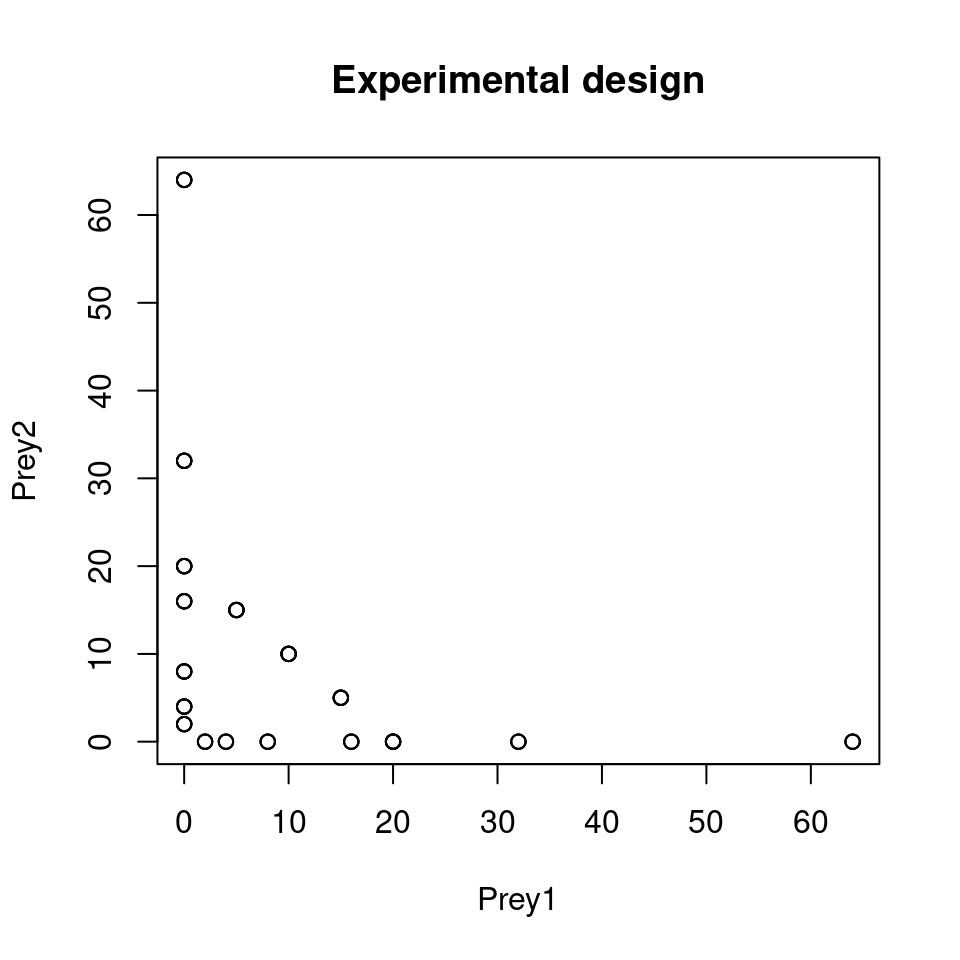

```r
df.single.1$Time = 8/24 # [days]
df.single.2$Time = 8/24
df.multi$Time = 2/24

df.single.1$Replaced = 0
df.single.2$Replaced = 0
df.multi$Replaced = 1

df.all = data.frame(Prey1 = c(df.single.1$Prey1, df.single.2$Prey1, df.multi$Prey1),
                    Prey2 = c(df.single.1$Prey2, df.single.2$Prey2, df.multi$Prey2),
                    Prey1.Eaten = c(df.single.1$Prey1.Eaten, df.single.2$Prey1.Eaten, df.multi$Prey1),
                    Prey2.Eaten = c(df.single.1$Prey2.Eaten, df.single.2$Prey2.Eaten, df.multi$Prey2),
                    Time = c(df.single.1$Time, df.single.2$Time, df.multi$Time),
                    Replaced = c(df.single.1$Replaced, df.single.2$Replaced, df.multi$Replaced)
)

plot(df.all[, c(1,2)], main="Experimental design")
```

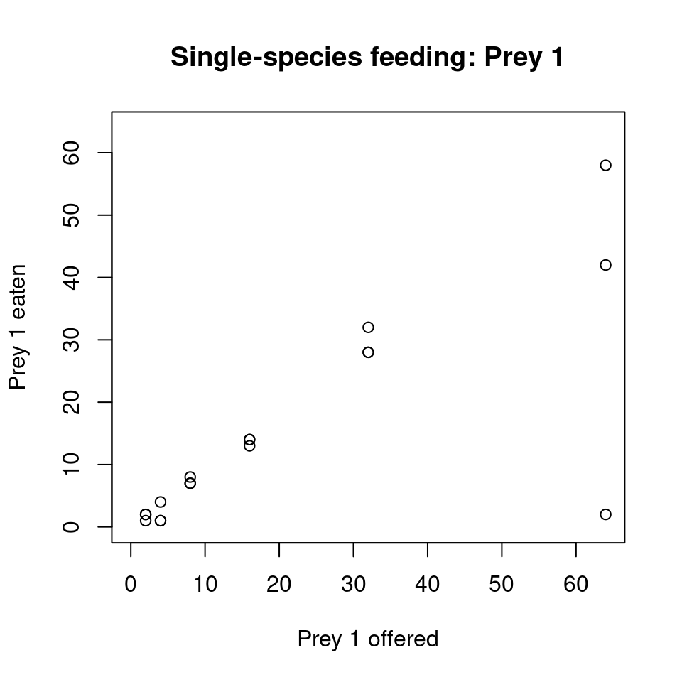

```r
plot(df.single.1$Prey1, df.single.1$Prey1.Eaten, xlim=c(0,64), ylim=c(0,64),
     xlab="Prey 1 offered", ylab="Prey 1 eaten",
     main="Single-species feeding: Prey 1")
```

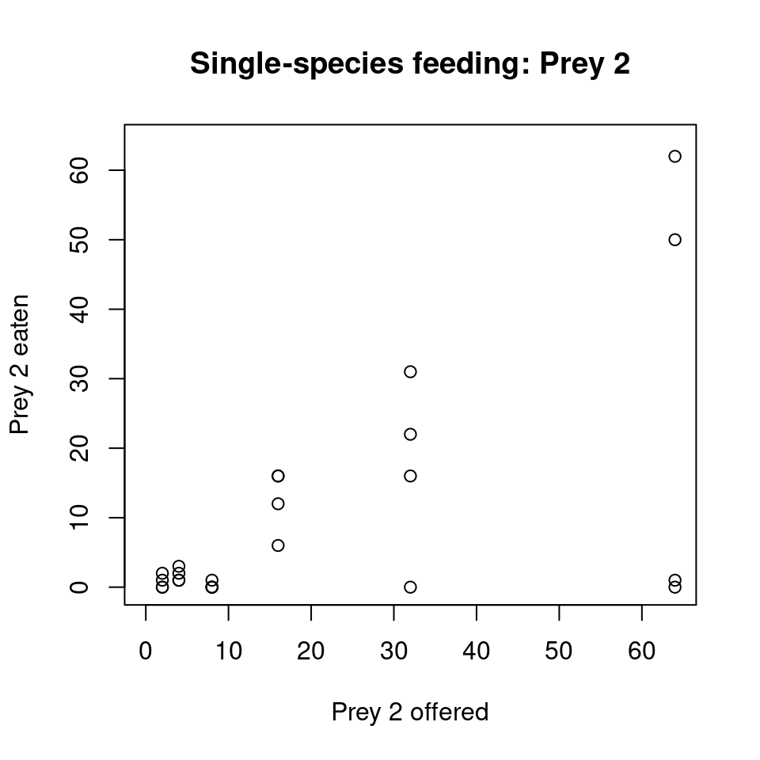

```r
plot(df.single.2$Prey2, df.single.2$Prey2.Eaten, xlim=c(0,64), ylim=c(0,64),
     xlab="Prey 2 offered", ylab="Prey 2 eaten",
     main="Single-species feeding: Prey 2")
```

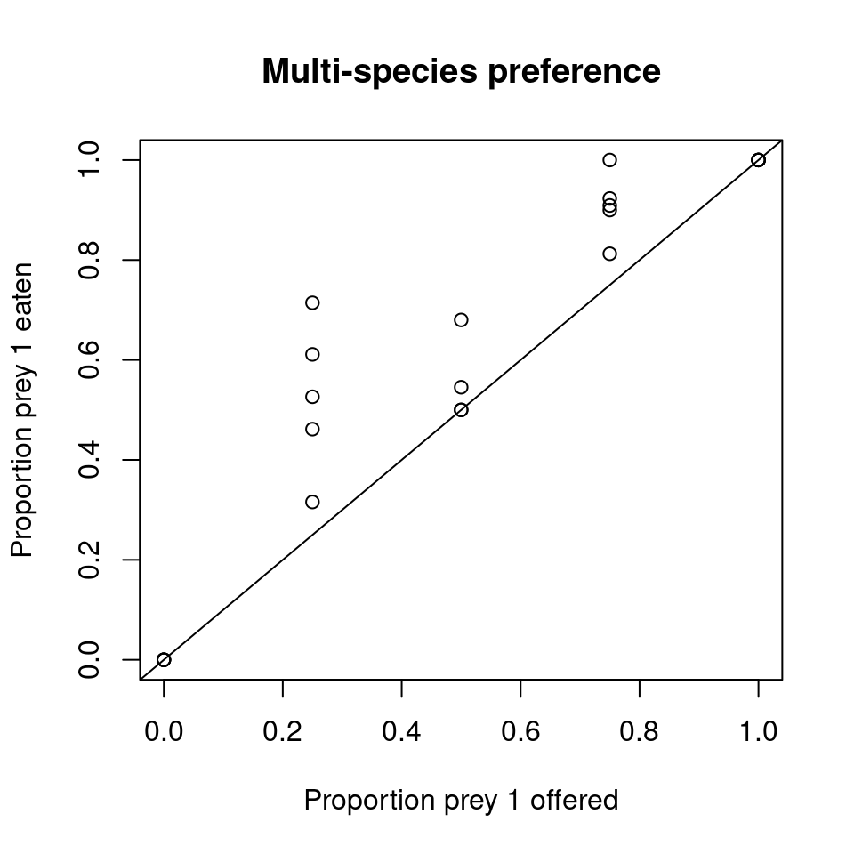

```r
plot(df.multi$Prey1/(df.multi$Prey1+df.multi$Prey2),
     df.multi$Prey1.Eaten/(df.multi$Prey1.Eaten+df.multi$Prey2.Eaten),
     xlim=c(0,1), ylim=c(0,1),
     xlab="Proportion prey 1 offered", ylab="Proportion prey 1 eaten",
     main="Multi-species preference")
abline(0,1)
```

Data has to be coded as a named list for `Stan`. Single- and multi-species experiments are different in their values for `Time` and `Replaced` (see above).

```r
data.stan = list(n = nrow(df.all),
                 m = 2,
                 N_0 = as.matrix(df.all[, 1:2]),
                 N_e = as.matrix(df.all[, 3:4]),
                 Time = df.all$Time,
                 Replaced = df.all$Replaced
)
```

## Model fitting

For all models, posterior distributions are sampled using 3 chains, 1000 warmup steps and 2000 sampling steps, each. Initial values `init` are provided for all parameters. Convergence of MCMC is verified through `Rhat` value close to 1 and sufficient number of effective samples `n_eff`.

```r
chains = 3
```

### Fit Holling 2

```r
init = rep(list(list(a = c(1,1),
                     h = c(1/100,1/100))
),chains)

fit1 = sampling(
  model.H2,
  data = data.stan,
  chains = chains,
  warmup = 1000,
  iter = 3000,
  cores = 3,
  init = init,
  refresh = 100
)
```

```r
print(fit1, pars=c("a","h"))
```

```
Inference for Stan model: anon_model.
3 chains, each with iter=3000; warmup=1000; thin=1;
post-warmup draws per chain=2000, total post-warmup draws=6000.

     mean se_mean   sd 2.5%  25%  50%  75% 97.5% n_eff Rhat
a[1] 8.39    0.01 0.72 7.07 7.89 8.37 8.86  9.90  3047    1
a[2] 4.97    0.01 0.39 4.24 4.72 4.96 5.22  5.76  2711    1
h[1] 0.00    0.00 0.00 0.00 0.00 0.00 0.00  0.00  2799    1
h[2] 0.00    0.00 0.00 0.00 0.00 0.00 0.00  0.01  2620    1

Samples were drawn using NUTS(diag_e) at Fri Nov  3 13:37:51 2023.
For each parameter, n_eff is a crude measure of effective sample size,
and Rhat is the potential scale reduction factor on split chains (at
convergence, Rhat=1).
```

### Fit Holling 3

```r
init = rep(list(list(a = c(0.5,0.5),
                     h = c(1/100,1/100),
                     q = 1)
),chains)

fit2 = sampling(
  model.H3,
  data = data.stan,
  chains = chains,
  warmup = 1000,
  iter = 3000,
  cores = 3,
  init = init,
  refresh = 100
)
```

```r
print(fit2, pars=c("a","h","q"))
```

```
Inference for Stan model: anon_model.
3 chains, each with iter=3000; warmup=1000; thin=1;
post-warmup draws per chain=2000, total post-warmup draws=6000.

     mean se_mean   sd 2.5%  25%  50%  75% 97.5% n_eff Rhat
a[1] 1.96    0.01 0.49 1.13 1.61 1.92 2.26  3.04  2226    1
a[2] 1.05    0.01 0.27 0.61 0.86 1.02 1.21  1.65  2249    1
h[1] 0.01    0.00 0.00 0.01 0.01 0.01 0.01  0.01  3932    1
h[2] 0.01    0.00 0.00 0.01 0.01 0.01 0.01  0.01  4059    1
q    1.13    0.00 0.13 0.88 1.04 1.12 1.21  1.38  2238    1

Samples were drawn using NUTS(diag_e) at Fri Nov  3 13:43:32 2023.
For each parameter, n_eff is a crude measure of effective sample size,
and Rhat is the potential scale reduction factor on split chains (at
convergence, Rhat=1).
```

### Fit Yodzis FR

```r
init = rep(list(list(a = c(1,1),
                     h = c(1/100,1/100),
                     w = c(0.5,0.5),
                     r = 1)
),chains)

fit3 = sampling(
  model.Yo,
  data = data.stan,
  chains = chains,
  warmup = 1000,
  iter = 3000,
  cores = 3,
  init = init,
  refresh = 100
)
```

```r
print(fit3, pars=c("a","h","w","r"))
```

```
Inference for Stan model: anon_model.
3 chains, each with iter=3000; warmup=1000; thin=1;
post-warmup draws per chain=2000, total post-warmup draws=6000.

      mean se_mean   sd  2.5%   25%   50%   75% 97.5% n_eff Rhat
a[1] 12.43    0.02 1.09 10.42 11.69 12.40 13.15 14.62  4119    1
a[2]  5.78    0.01 0.46  4.94  5.47  5.76  6.08  6.73  3939    1
h[1]  0.01    0.00 0.00  0.00  0.00  0.01  0.01  0.01  4511    1
h[2]  0.01    0.00 0.00  0.00  0.00  0.01  0.01  0.01  4171    1
w[1]  0.42    0.00 0.04  0.35  0.39  0.42  0.44  0.49  4802    1
w[2]  0.58    0.00 0.04  0.51  0.56  0.58  0.61  0.65  4802    1
r     0.54    0.00 0.15  0.25  0.44  0.54  0.64  0.84  4822    1

Samples were drawn using NUTS(diag_e) at Fri Nov  3 13:48:10 2023.
For each parameter, n_eff is a crude measure of effective sample size,
and Rhat is the potential scale reduction factor on split chains (at
convergence, Rhat=1).
```

### Fit New FR

```r
init = rep(list(list(a = c(0.5,0.5),
                     h = c(1/100,1/100),
                     w = c(0.5,0.5),
                     q = 0.5,
                     r = 0.5)
),chains)

fit4 = sampling(
  model.New,
  data = data.stan,
  chains = chains,
  warmup = 1000,
  iter = 3000,
  cores = 3,
  init = init,
  refresh = 100
)
```

```r
print(fit4, pars=c("a","h","w","q","r"))
```

```
Inference for Stan model: anon_model.
3 chains, each with iter=3000; warmup=1000; thin=1;
post-warmup draws per chain=2000, total post-warmup draws=6000.

     mean se_mean   sd 2.5%  25%  50%  75% 97.5% n_eff Rhat
a[1] 4.07    0.02 1.32 1.99 3.14 3.89 4.81  7.14  4697    1
a[2] 0.62    0.00 0.19 0.32 0.49 0.60 0.73  1.05  4215    1
h[1] 0.01    0.00 0.00 0.01 0.01 0.01 0.01  0.01  6554    1
h[2] 0.01    0.00 0.00 0.01 0.01 0.01 0.01  0.01  7051    1
w[1] 0.20    0.00 0.05 0.12 0.17 0.20 0.24  0.31  5126    1
w[2] 0.80    0.00 0.05 0.69 0.76 0.80 0.83  0.88  5126    1
q    1.44    0.00 0.14 1.19 1.35 1.44 1.53  1.72  4303    1
r    0.03    0.00 0.03 0.00 0.01 0.02 0.04  0.11  7694    1

Samples were drawn using NUTS(diag_e) at Fri Nov  3 13:55:38 2023.
For each parameter, n_eff is a crude measure of effective sample size,
and Rhat is the potential scale reduction factor on split chains (at
convergence, Rhat=1).
```

## Model comparison

Extract log-likelihood values for all fits and compute predictive performance with leave-one-out cross validation using the `loo` package.

```r
lik1 = extract_log_lik(fit1, merge_chains=FALSE)
reff1 = relative_eff(exp(lik1), cores=4)
loo1 = loo(lik1, r_eff=reff1, cores=4)

lik2 = extract_log_lik(fit2, merge_chains=FALSE)
reff2 = relative_eff(exp(lik2), cores=4)
loo2 = loo(lik2, r_eff=reff2, cores=4)

lik3 = extract_log_lik(fit3, merge_chains=FALSE)
reff3 = relative_eff(exp(lik3), cores=4)
loo3 = loo(lik3, r_eff=reff3, cores=4)

lik4 = extract_log_lik(fit4, merge_chains=FALSE)
reff4 = relative_eff(exp(lik4), cores=4)
loo4 = loo(lik4, r_eff=reff4, cores=4)

loo_compare(loo1, loo2, loo3, loo4)
```

```
       elpd_diff se_diff
model2    0.0       0.0
model4  -13.1       9.5
model1  -33.6      31.3
model3 -121.9      28.2
```

Holling 3 has the highest `elpd` score, but including uncertainty (`se_diff`) it is equivalent to Holling-2. Due to parsimony, Holling-2 is identified as the best fitting model.

Its posterior distributions of all parameters and their multivariate correlation are plotted.

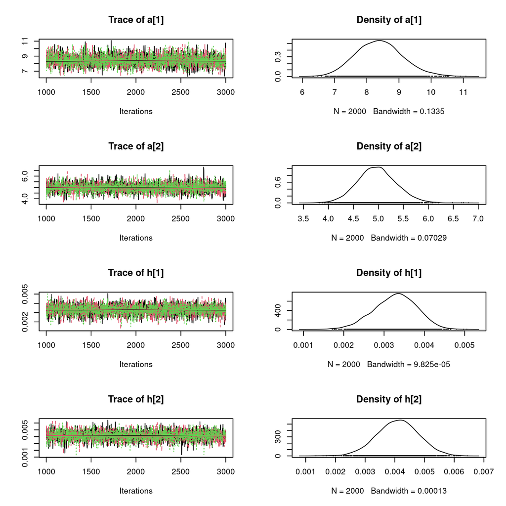

```r
plot(As.mcmc.list(fit1)[, 1:4])
```

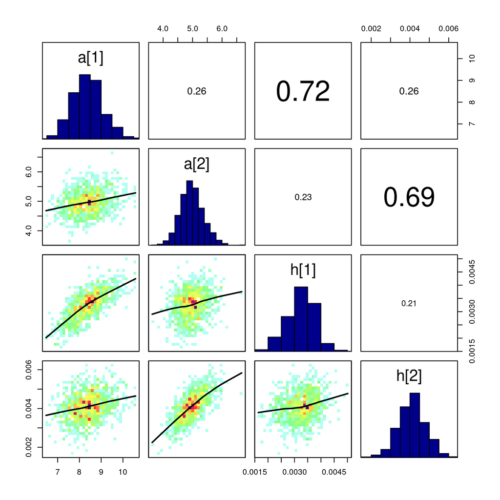

```r
correlationPlot(as.matrix(fit1)[, 1:4])
```

## Posterior predictions for best fitting model

The correct `MSFR` model function is selected, which has the output (negative) functional response. 1000 samples from the posterior distribution are chosen randomly. For single-species experiments, predictions are generated through numerical simulation of ODEs with a duration of 8/24 day. In multi-species experiments prey were replaced, predictions are computed directly as feeding rate multiplied by experimental duration (2/24 day). Their median and 90% credible intervals are plotted against observed data.

```r
MSFR = Holling2

n.post = 1000
n.pred = 20
post = as.matrix(fit1)[, 1:4]
set.seed(100)
post = post[sample(1:nrow(post),n.post), ]
```

### Single-species prey 1

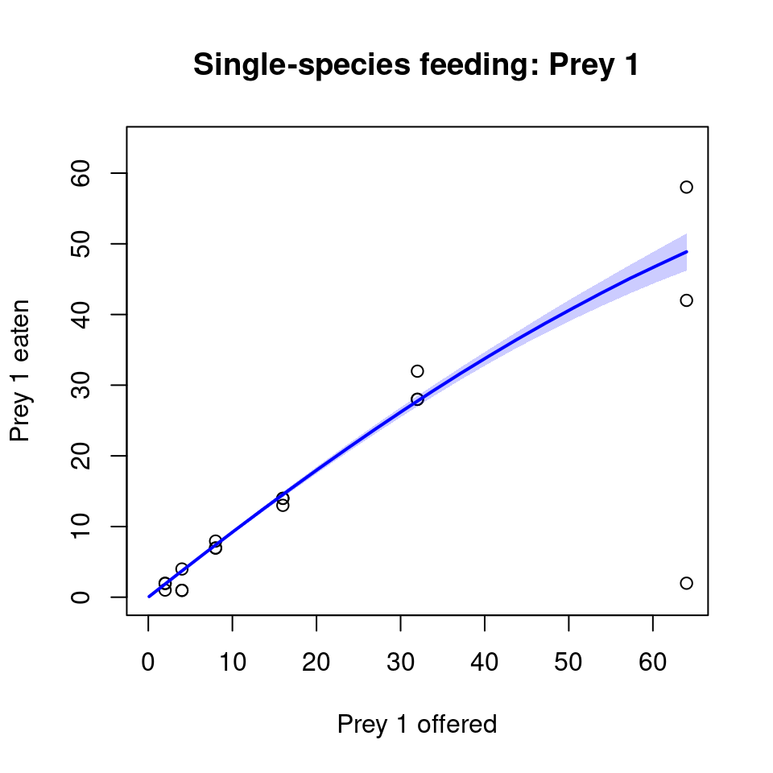

```r
N10.pred = seq(0.1, 64, length.out=n.pred)
N1E.pred = matrix(NA, nrow=n.post, ncol=n.pred)

for(k in 1:n.post){
  params = list(a=post[k, 1:2],
                h=post[k, 3:4],
                m=2)
  for(i in 1:n.pred){
    out = ode(y = c(N=c(N10.pred[i], 0.0)), times = c(0,8/24), func = MSFR, parms = params)
    N1E.pred[k,i] = N10.pred[i]-out[2,2]
  }
}

N1E.pred.qs = apply(N1E.pred, 2, function(x) quantile(x, probs=c(0.05, 0.5, 0.95)))

plot(df.single.1$Prey1, jitter(df.single.1$Prey1.Eaten, factor=0.3),
     xlim=c(0,64), ylim=c(0,64),
     xlab="Prey 1 offered", ylab="Prey 1 eaten",
     main="Single-species feeding: Prey 1")
polygon( c(N10.pred, rev(N10.pred)),
         c(N1E.pred.qs[1, ], rev(N1E.pred.qs[3, ])),
         border=NA,
         col=adjustcolor("blue", alpha.f=0.2)
)
lines(N10.pred, N1E.pred.qs[2, ], col="blue", lwd=2)
```

### Single-species prey 2

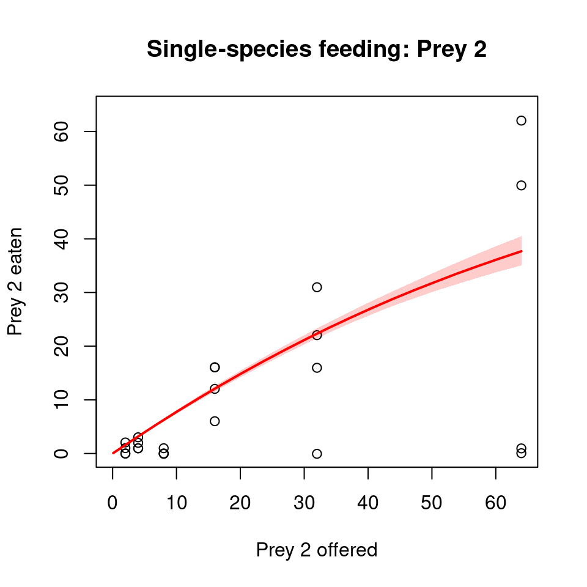

```r
N20.pred = seq(0.1, 64, length.out=n.pred)
N2E.pred = matrix(NA, nrow=n.post, ncol=n.pred)

for(k in 1:n.post){
  params = list(a=post[k, 1:2],
                h=post[k, 3:4],
                m=2)
  for(i in 1:n.pred){
    out = ode(y = c(N=c(0.0, N20.pred[i])), times = c(0,8/24), func = MSFR, parms = params)
    N2E.pred[k,i] = N20.pred[i]-out[2,3]
  }
}

N2E.pred.qs = apply(N2E.pred, 2, function(x) quantile(x, probs=c(0.05, 0.5, 0.95)))

plot(df.single.2$Prey2, jitter(df.single.2$Prey2.Eaten, factor=0.3),
     xlim=c(0,64), ylim=c(0,64),
     xlab="Prey 2 offered", ylab="Prey 2 eaten",
     main="Single-species feeding: Prey 2")
polygon( c(N20.pred, rev(N20.pred)),
         c(N2E.pred.qs[1, ], rev(N2E.pred.qs[3, ])),
         border=NA,
         col=adjustcolor("red", alpha.f=0.2)
)
lines(N20.pred, N2E.pred.qs[2, ], col="red", lwd=2)
```

### Multi-species relative consumption

Multi-species predictions are computed along a gradient of relative composition of N1 and N2 with N1+N2=20.

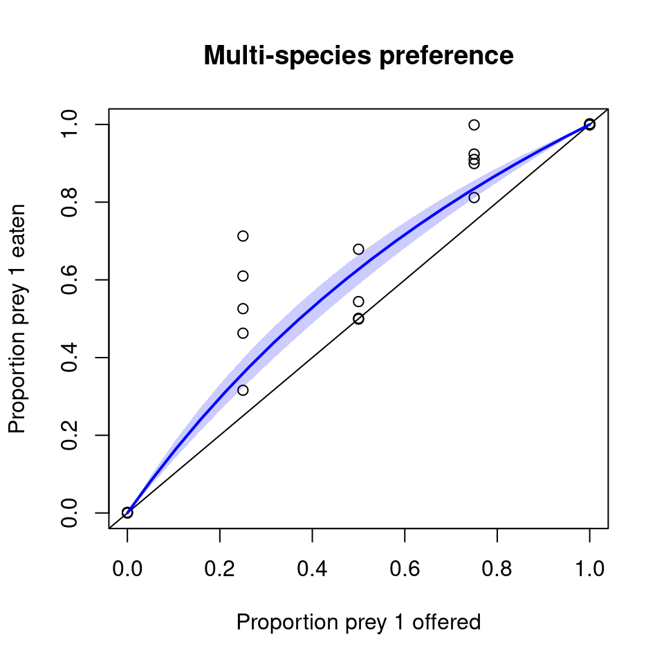

```r
N0.total = 20

N10.pred = seq(0, N0.total, length.out=n.pred)
N20.pred = N0.total-N10.pred
N1E.pred = matrix(NA, nrow=n.post, ncol=n.pred)
N2E.pred = matrix(NA, nrow=n.post, ncol=n.pred)

for(k in 1:n.post){
  params = list(a=post[k, 1:2],
                h=post[k, 3:4],
                m=2)
  for(i in 1:n.pred){
    out = -(2/24)*unlist(MSFR(t=0, N=c(N10.pred[i], N20.pred[i]), parms=params))
    N1E.pred[k,i] = out[1]
    N2E.pred[k,i] = out[2]
  }
}

N1E.pred.qs = apply(N1E.pred, 2, function(x) quantile(x, probs=c(0.05, 0.5, 0.95)))
N2E.pred.qs = apply(N2E.pred, 2, function(x) quantile(x, probs=c(0.05, 0.5, 0.95)))

# make relative
N1E.pred.rel = matrix(NA, nrow=n.post, ncol=n.pred)
N2E.pred.rel = matrix(NA, nrow=n.post, ncol=n.pred)
for(k in 1:n.post){
  N1E.pred.rel[k, ] = N1E.pred[k, ]/(N1E.pred[k, ]+N2E.pred[k, ])
  N2E.pred.rel[k, ] = N2E.pred[k, ]/(N1E.pred[k, ]+N2E.pred[k, ])
}

N1E.pred.rel.qs = apply(N1E.pred.rel, 2, function(x) quantile(x, probs=c(0.05, 0.5, 0.95)))
N2E.pred.rel.qs = apply(N2E.pred.rel, 2, function(x) quantile(x, probs=c(0.05, 0.5, 0.95)))

plot(df.multi$Prey1/(df.multi$Prey1+df.multi$Prey2),
     jitter(df.multi$Prey1.Eaten/(df.multi$Prey1.Eaten+df.multi$Prey2.Eaten),factor=1),
     xlim=c(0,1), ylim=c(0,1),
     xlab="Proportion prey 1 offered", ylab="Proportion prey 1 eaten",
     main="Multi-species preference")
abline(0,1)
polygon( c(N10.pred/N0.total, rev(N10.pred/N0.total)),
         c(N1E.pred.rel.qs[1, ], rev(N1E.pred.rel.qs[3, ])),
         border=NA,
         col=adjustcolor("blue", alpha.f=0.2)
)
lines(N10.pred/N0.total, N1E.pred.rel.qs[2, ], col="blue", lwd=2)
```

The model predicts a preference for prey 1.

### Multi-species feeding

Since multi-species experiments were performed with a fixed number of total prey only (N1+N2=20), predicted feeding rates on both species can be plotted along this gradient against the data.

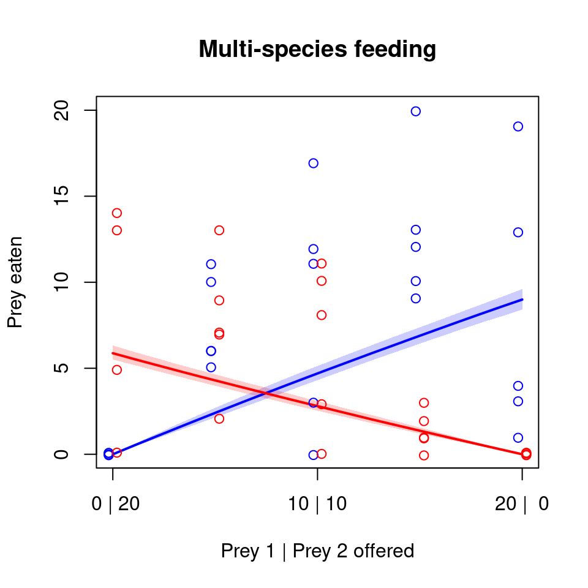

```r
plot(NA, xlim=c(0,20), ylim=c(0,20), xaxt="n", ylab="", xlab="",
     main="Multi-species feeding")
title(ylab="Prey eaten", xlab="Prey 1 | Prey 2 offered")
axis(1, at = c(0,10,20), labels = c(" 0 | 20", "10 | 10", "20 |  0"))
polygon( c(N10.pred, rev(N10.pred)),
         c(N1E.pred.qs[1, ], rev(N1E.pred.qs[3, ])),
         border=NA,
         col=adjustcolor("blue", alpha.f=0.2)
)
polygon( c(20-N20.pred, rev(20-N20.pred)),
         c(N2E.pred.qs[1, ], rev(N2E.pred.qs[3, ])),
         border=NA,
         col=adjustcolor("red", alpha.f=0.2)
)
lines(N10.pred, N1E.pred.qs[2, ], col="blue", lwd=2)
lines(20-N20.pred, N2E.pred.qs[2, ], col="red", lwd=2)
points(df.multi$Prey1-0.2,
       jitter(df.multi$Prey1.Eaten, factor=0.5),
       col="blue")
points(20-(df.multi$Prey2)+0.2, # reverse
       jitter(df.multi$Prey2.Eaten, factor=0.5),
       col="red")
```

### Multi-species observed vs. predicted

Additionally, median predicted numbers of eaten prey (N1E and N2E) are computed and plotted against observed data points.

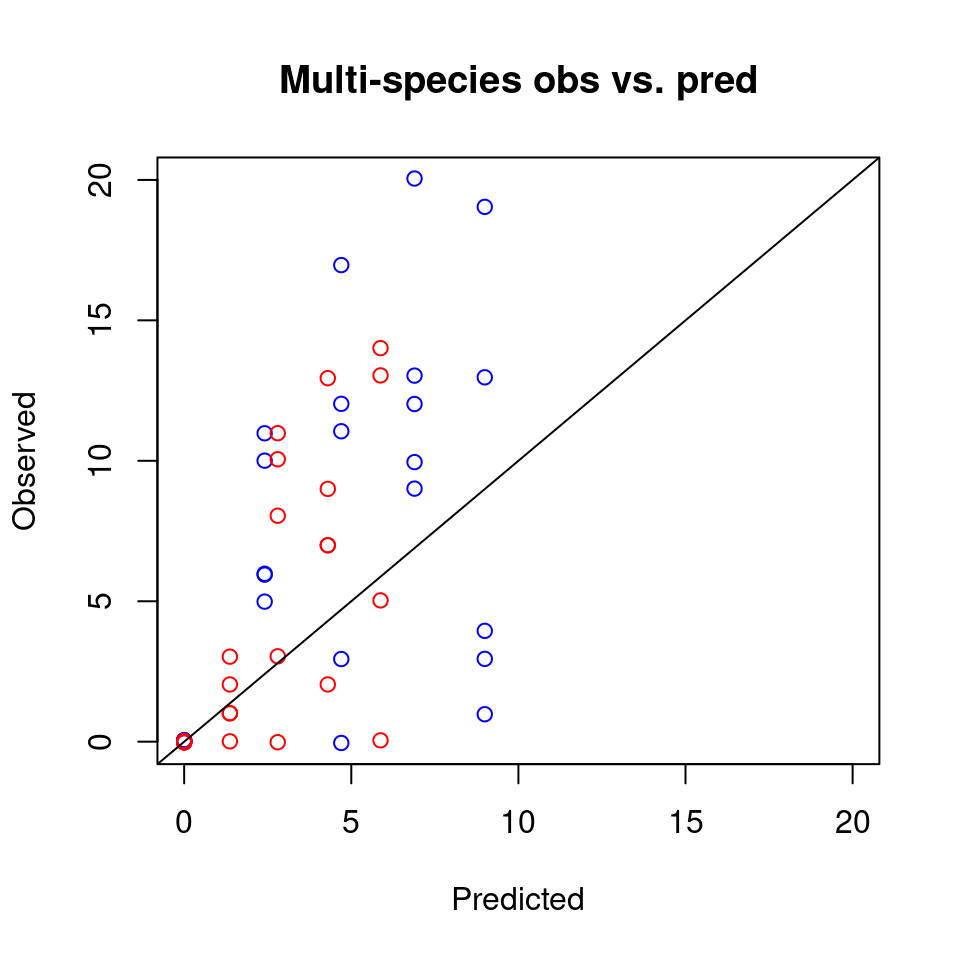

```r
N1E.pred = matrix(NA, nrow=n.post, ncol=nrow(df.multi))
N2E.pred = matrix(NA, nrow=n.post, ncol=nrow(df.multi))

for(k in 1:n.post){
  params = list(a=post[k, 1:2],
                h=post[k, 3:4],
                m=2)
  for(i in 1:nrow(df.multi)){
    out = -(2/24)*unlist(MSFR(t=0, N=c(df.multi$Prey1[i],df.multi$Prey2[i]), parms=params))
    N1E.pred[k,i] = out[1]
    N2E.pred[k,i] = out[2]
  }
}

N1E.pred.qs = apply(N1E.pred, 2, function(x) quantile(x, probs=c(0.05, 0.5, 0.95)))
N2E.pred.qs = apply(N2E.pred, 2, function(x) quantile(x, probs=c(0.05, 0.5, 0.95)))

plot(NULL, xlim=c(0,20), ylim=c(0,20), xlab="Predicted", ylab="Observed",
     main="Multi-species obs vs. pred")
points(N1E.pred.qs[2, ], jitter(df.multi$Prey1.Eaten, factor=0.3), col="blue")
points(N2E.pred.qs[2, ], jitter(df.multi$Prey2.Eaten, factor=0.3), col="red")
abline(0,1)
```